# Calculate and Plot the Log2-Fold Abundance Ratio

Marian L. Schmidt

December, 17, 2014

### Objective

An odds-ratio is a good way to quantify and visualize how strong of an association a variable (in this case 16S tag-sequence abundance data) is between different exposures. By exposure, I mean any categorical variable. For example, it could be the experimentally-manipulated versus the control, or one treatment versus another or, as it is in the case of the example data, the surface of the lake versus the bottom of a lake during summer stratification.

The objective of the functions below is to three-fold:  
**1.** Create an abundance plot with standard errors.  
**2.** Calculate a log2-fold abundance ratio.  
**3.** Plot the log2-fold abundance ratio.

### Input Data

The input data should be in the form of a data frame with **column names** that include:

- **Phylum:** Name of the Phylum of the organisms.
- **SeqAbundance:** Sequence abundance for that sample.
- **PercentPhylum:** The percent abundance of the sequences in that sample.
- One or more columns of categorical data.
  - **Note:** The categorical data must only include 2 factors.

```r
data <- read.csv("InputData_ProdTop.csv", header = TRUE)
require(knitr)
kable(head(data[(1:3),]), format = "markdown")
```

| sample | Phylum | SeqAbundance | PercentPhylum | trophicstate | filter | limnion |
| --- | --- | --- | --- | --- | --- | --- |
| BAKE1 | Alphaproteobacteria | 385 | 3.74 | Productive | Free | Top |
| BAKE1 | Betaproteobacteria | 2116 | 20.53 | Productive | Free | Top |
| BAKE1 | Deltaproteobacteria | 345 | 3.35 | Productive | Free | Top |

In the above dataframe “trophicstate”, “filter” and “limnion” are all categories that include 2 factors.

### Functions

**Important note:** These functions require the summarySE function from the R Cookbook. Here, I have added the function to a text file called “RCookbook_summarySE.R” that I source within the functions.

- **abundPlot:** Calculates the standard error and then plots the relative abundances based on a column in the input dataframe named “PercentPhylum”.
- **log2fold_calc:** Calculates the log2-fold abundance odds ratio with column named SeqAbundance based on factor of your choosing.
  - **Input:** A dataframe and a category. *Must use quotes around the category!
  - **Output:** A list containing 2 variables including:
    1. *deleted_data:* Data frame of deleted data including Infs, -Infs, and NaN.
    2. *ratio_data:* Data frame of log2-fold abundance ratio to beused in oddsratio_plot function.
- **oddsratio_plot:** Creates a graph with the log2fold_calc output function.
  - **Input:** The following 3 things:
    1. The ratio_data output from the log2fold_calc function.
    2. First Legend Label.
    3. Second Legend Label.
  - **Output:** A pretty graph with the listed legend labels.

#### Before we go odds ratio-ing, let’s make a plot of the relative abundances first!

##### We can use the abundPlot function

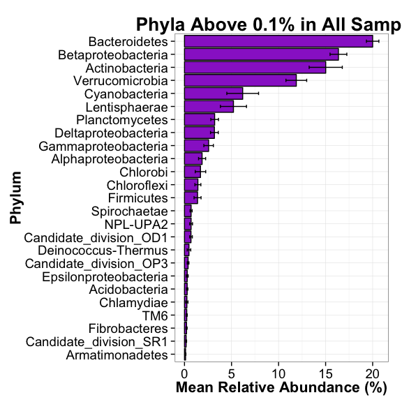

```r
abundPlot <- function(dataframe){ #uses PercentPhylum column to make an abundance plot
  source("RCookbook_summarySE.R")
  require(ggplot2)
  sum_stats <- summarySE(dataframe, measurevar = "PercentPhylum", groupvars = "Phylum") #sum_stats is a data frame for the relative abundance figure
  sum_stats$Phylum <- factor(sum_stats$Phylum, levels = sum_stats$Phylum[order(sum_stats$PercentPhylum)])  #Order by the SeqAbundance
  abund <- subset(sum_stats,PercentPhylum > 0.1)
  abundPlot <- ggplot(abund, aes(y=PercentPhylum, x=Phylum))  +
  geom_bar(stat="identity", position=position_dodge(),  fill = "darkorchid3", colour = "black") +
  theme_bw() + ggtitle("Phyla Above 0.1% in All Samples") +
  xlab("Phylum") + ylab("Mean Relative Abundance (%)") +
  geom_errorbar(aes(ymin = PercentPhylum -se, ymax = PercentPhylum +se), width = 0.25) + coord_flip() +
  theme(axis.title.x = element_text(face="bold", size=16),
        axis.text.x = element_text(angle=0, colour = "black", size=14),
        axis.text.y = element_text(colour = "black", size=14),
        axis.title.y = element_text(face="bold", size=16),
        plot.title = element_text(face="bold", size = 20),
        legend.title = element_text(size=12, face="bold"),
        legend.text = element_text(size = 12),
        legend.position="none")
  return(abundPlot)
}

abundPlot(data)
```

#### To Calculate and Plot the Log2-Fold Abundance Ratio

##### Calculate with log2fold_calc function

##### Plot with oddsratio_plot

```r
#This function takes one dataframe and a category to make a log2-fold abundance ratio dataframe
#Must put category in quotes!
log2fold_calc <- function(dataframe, category){  #must have SeqAbundance and Phylum columns, category column must only have 2 categories.
  source("RCookbook_summarySE.R")
  stats <- summarySE(dataframe, measurevar = "SeqAbundance", groupvars = c(category, "Phylum"))
  colnames(stats)[which(names(stats) == "SeqAbundance")] <- "Mean_SeqAbundance"  #Change column name to represent what value really is
  erp <- split(stats, stats[,category])  ### make 2 data frames and split the 2
  dataframe1 <- erp[[2]]
  dataframe2 <- erp[[1]]
  #Make a new data frame with the log2-fold ratio
  data_ratio <- log2(dataframe1$Mean_SeqAbund/dataframe2$Mean_SeqAbund) #creates a vector with log2 values
  data_ratio <- data.frame(dataframe2$Phylum, data_ratio) #combine the Phylum names with it
  names(data_ratio)[1:2]<-c("Phylum", "Ratio") #Rename the column names to better represent
  #Help to position labels on graph:  http://learnr.wordpress.com/2009/06/01/ggplot2-positioning-of-barplot-category-labels/
  data_ratio$colour <- ifelse(data_ratio$Ratio < 0, "firebrick1","steelblue") #Adds a column with 2 colors for easy plotting
  data_ratio$hjust <- ifelse(data_ratio$Ratio > 0, 1.3, -0.3) # This is where the labels on the Y axis of the plot will be placed
  #Now we have to delete Phyla from our data frame that are Inf, -Inf, or NaN
  sub_data <- subset(data_ratio, data_ratio$Ratio != "Inf" & data_ratio$Ratio != "-Inf" & data_ratio$Ratio != "NaN")
  sub_data$Phylum <- factor(sub_data$Phylum, levels = sub_data$Phylum[order(sub_data$Ratio)])
  deleted_phy <- subset(data_ratio, data_ratio$Ratio == "Inf" | data_ratio$Ratio == "-Inf" | data_ratio$Ratio == "NaN")
  return(list(deleted_data = deleted_phy, ratio_data = sub_data))
}



#The following function will create a plot out of the "ratio_data" output from the log2fold_calc function above.
#Must put legend names in quotes!
oddsratio_plot <- function(dataframe, legend_label1, legend_label2){
  require(ggplot2)
  plot <- ggplot(dataframe, aes(y=Ratio, x = Phylum, label = Phylum, hjust=hjust, fill = colour)) +
  geom_bar(stat="identity", position=position_dodge(), colour = "black") +
  geom_text(aes(y=0, fill = colour)) + theme_bw() + ylim(min(dataframe$Ratio),max(dataframe$Ratio)) +
  coord_flip() + ggtitle("Odds Ratio Plot") +
  labs(y = "Log2-Fold Abundance Ratio", x = "") + scale_x_discrete(breaks = NULL) +
  scale_fill_manual(name  ="", breaks=c("steelblue", "firebrick1"),
                    labels=c(legend_label1, legend_label2),
                    values = c("magenta4", "darkorange")) +
  theme(axis.title.x = element_text(face="bold", size=16),
        axis.text.x = element_text(angle=0, colour = "black", size=14),
        axis.text.y = element_text(colour = "black", size=12),
        axis.title.y = element_text(face="bold", size=16),
        plot.title = element_text(face="bold", size = 16),
        legend.title = element_text(size=12, face="bold"),
        legend.text = element_text(size = 12),
        legend.justification=c(1,0), legend.position="right");
  return(plot)
}
```

### Example Dataset Using the Functions

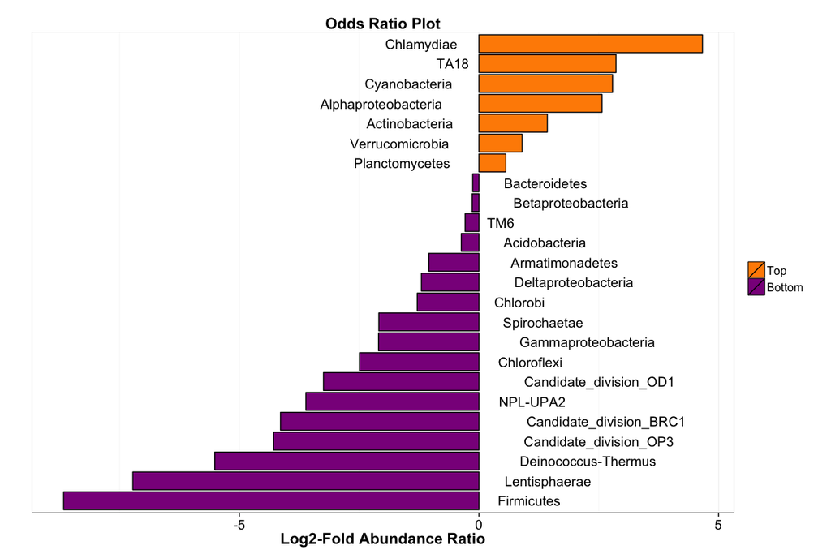

```r
freeprod <- log2fold_calc(data, "limnion")
freeprod_data <- freeprod$ratio_data
oddsratio_plot(freeprod_data, "Top", "Bottom")
```